# Анализ рынка недвижимости Санкт-Петербурга

# Содержание

В нашем распоряжении данные сервиса Яндекc Недвижимость — архив объявлений о продаже квартир в Санкт-Петербурге и соседних населённых пунктах за несколько лет. Нужно научиться определять рыночную стоимость объектов недвижимости. Наша задача — установить параметры. Это позволит построить автоматизированную систему: она отследит аномалии и мошенническую деятельность.

По каждой квартире на продажу доступны два вида данных:

1. Первые вписаны пользователем.
2. Вторые получены автоматически на основе картографических данных. Например, расстояние до центра, аэропорта, ближайшего парка и водоёма.

**Конкретизируем задачу:** необходимо установить зависимость конечной цены проданной квартиры от её различных параметров, а также сформулировать предложения по составу ключевых параметров будущей системы отслеживания объявлений

Данная конкретизация справедлива, поскольку текущая цена непроданных квартир часто зависит от субъективных факторов: жадности продавцов, ажиотажа на рынке и т.п.

## Изучение данных

Импортируем необходимые библиотеки, загрузим данные из файла и выведем 5 случайных строк:

```python
import matplotlib.pyplot as plt
import pandas as pd
import math

try:
    realty = pd.read_csv('/datasets/real_estate_data.csv', sep='\t')
except:
    realty = pd.read_csv('real_estate_data.csv.csv', sep='\t')

realty.sample(5)
```

|  | total_images | last_price | total_area | first_day_exposition | rooms | ceiling_height | floors_total | living_area | floor | is_apartment | ... | kitchen_area | balcony | locality_name | airports_nearest | cityCenters_nearest | parks_around3000 | parks_nearest | ponds_around3000 | ponds_nearest | days_exposition |
| --- | --- | --- | --- | --- | --- | --- | --- | --- | --- | --- | --- | --- | --- | --- | --- | --- | --- | --- | --- | --- | --- |
| 2931 | 14 | 2550000.0 | 44.0 | 2018-08-08T00:00:00 | 2 | 2.6 | 2.0 | 26.0 | 1 | NaN | ... | 8.0 | 2.0 | деревня Вартемяги | NaN | NaN | NaN | NaN | NaN | NaN | 216.0 |
| 580 | 16 | 5270000.0 | 56.7 | 2019-02-07T00:00:00 | 3 | 2.5 | 5.0 | 42.0 | 3 | NaN | ... | 5.1 | NaN | Санкт-Петербург | 14738.0 | 13279.0 | 1.0 | 580.0 | 1.0 | 268.0 | NaN |
| 22849 | 6 | 2380000.0 | 25.0 | 2016-03-22T00:00:00 | 1 | NaN | 25.0 | 19.0 | 15 | NaN | ... | 4.0 | 1.0 | посёлок Шушары | 13461.0 | 19247.0 | 0.0 | NaN | 1.0 | 351.0 | 140.0 |
| 14013 | 7 | 2700000.0 | 36.6 | 2017-11-26T00:00:00 | 1 | NaN | 18.0 | 23.0 | 2 | NaN | ... | 8.3 | NaN | Всеволожск | NaN | NaN | NaN | NaN | NaN | NaN | 5.0 |
| 6827 | 0 | 4070000.0 | 60.0 | 2017-08-15T00:00:00 | 3 | NaN | 9.0 | 42.9 | 8 | NaN | ... | 6.2 | 2.0 | Санкт-Петербург | 19159.0 | 18161.0 | 0.0 | NaN | 1.0 | 65.0 | 17.0 |

5 rows × 22 columns

### Обзор данных

Выведем общую информацию о таблице:

```python
realty.info()
```

```
<class 'pandas.core.frame.DataFrame'>
RangeIndex: 23699 entries, 0 to 23698
Data columns (total 22 columns):
 #   Column                Non-Null Count  Dtype
---  ------                --------------  -----
 0   total_images          23699 non-null  int64
 1   last_price            23699 non-null  float64
 2   total_area            23699 non-null  float64
 3   first_day_exposition  23699 non-null  object
 4   rooms                 23699 non-null  int64
 5   ceiling_height        14504 non-null  float64
 6   floors_total          23613 non-null  float64
 7   living_area           21796 non-null  float64
 8   floor                 23699 non-null  int64
 9   is_apartment          2775 non-null   object
 10  studio                23699 non-null  bool
 11  open_plan             23699 non-null  bool
 12  kitchen_area          21421 non-null  float64
 13  balcony               12180 non-null  float64
 14  locality_name         23650 non-null  object
 15  airports_nearest      18157 non-null  float64
 16  cityCenters_nearest   18180 non-null  float64
 17  parks_around3000      18181 non-null  float64
 18  parks_nearest         8079 non-null   float64
 19  ponds_around3000      18181 non-null  float64
 20  ponds_nearest         9110 non-null   float64
 21  days_exposition       20518 non-null  float64
dtypes: bool(2), float64(14), int64(3), object(3)
memory usage: 3.7+ MB
```

Всего таблица состоит из 23699 строк, 22 столбцов и содержит данные следующих типов: bool(2 столбца), float64(14 столбцов), int64(3 столбца), object(3 столбца).

Каждая строка соответствует описанию одного объекта недвижимости.

Столбцы `cityCenters_nearest`, `parks_around3000`, `ponds_around3000` озаглавлены в смешаном стиле. На этапе предобработки следует их переименовать.

Сопоставим предоставленную документацию к таблице с выявленными фактическими типами данных:

- airports_nearest — расстояние до ближайшего аэропорта в метрах (м) - float64
- balcony — число балконов - float64
- ceiling_height — высота потолков (м) - float64
- cityCenters_nearest — расстояние до центра города (м) - float64
- days_exposition — сколько дней было размещено объявление (от публикации до снятия) - float64
- first_day_exposition — дата публикации - object
- floor — этаж - int64
- floors_total — всего этажей в доме - float64
- is_apartment — апартаменты (булев тип) - object
- kitchen_area — площадь кухни в квадратных метрах (м²) - float64
- last_price — цена на момент снятия с публикации - float64
- living_area — жилая площадь в квадратных метрах (м²) - float64
- locality_name — название населённого пункта - object
- open_plan — свободная планировка (булев тип) - bool
- parks_around3000 — число парков в радиусе 3 км - float64
- parks_nearest — расстояние до ближайшего парка (м) - float64
- ponds_around3000 — число водоёмов в радиусе 3 км - float64
- ponds_nearest — расстояние до ближайшего водоёма (м) - float64
- rooms — число комнат - int64
- studio — квартира-студия (булев тип) - bool
- total_area — площадь квартиры в квадратных метрах (м²) - float64
- total_images — число фотографий квартиры в объявлении - int64

Из сопоставления видно, что *не все фактические типы данных соответствуют подразумеваемым*. На этапе предобработки целесообразно осуществить следующее преобразование типов.

1. К типу **bool** - столбец `is_apartment`, представленный в строковом типе.
2. К типу **int64** - столбцы:
   - `ponds_around3000`, т.к. количество водоёмов не может выражаться вещественным числом;
   - `parks_around3000`, т.к. количество парков не может выражаться вещественным числом;
   - `floors_total`, т.к. количество этажей не может выражаться вещественным числом;
   - `days_exposition` - несмотря на то, что количество дней может выражаться вещественным числом, в контексте исследования нас скорее будет интересовать целочисленная длинельность размещения, что позволит при необходимости категоризовать данное поле для удобства исследования;
   - `balcony`, т.к. количество балконов не может выражаться вещественным числом.
1. К типу **datetime64** - столбец `first_day_exposition`, содержащий даты, выраженные строками.

Разделим столбцы на заполняемые пользователем и рассчитываемые автоматически (это позволит преоположить характер возникновения аномалий в данных):

- столбцы, заполняемые пользователем:
  - balcony
  - ceiling_height
  - floor
  - floors_total
  - is_apartment
  - kitchen_area
  - living_area
  - locality_name
  - open_plan
  - rooms
  - studio
  - total_area
- столбцы, заполняемые автоматически:
  - airports_nearest
  - cityCenters_nearest
  - days_exposition
  - first_day_exposition
  - last_price
  - parks_around3000
  - parks_nearest
  - ponds_around3000
  - ponds_nearest
  - total_images

Также в таблице наблюдаются пропуски в ряде колонок данных. Оценим количество этих пропусков в разных колонках.

```python
realty.isna().sum()
```

```
total_images                0
last_price                  0
total_area                  0
first_day_exposition        0
rooms                       0
ceiling_height           9195
floors_total               86
living_area              1903
floor                       0
is_apartment            20924
studio                      0
open_plan                   0
kitchen_area             2278
balcony                 11519
locality_name              49
airports_nearest         5542
cityCenters_nearest      5519
parks_around3000         5518
parks_nearest           15620
ponds_around3000         5518
ponds_nearest           14589
days_exposition          3181
dtype: int64
```

На первый взгляд пропусков много, в некоторых столбцах - более половины. Отсортируем их в процентном выражении:

```python
(pd.DataFrame(
    round((realty.isna().mean()*100),2), columns=['NaNs, %'])
    .sort_values(by='NaNs, %', ascending=False)
    .style.format('{:.2f}')
    .background_gradient('coolwarm')
)
```

|  | NaNs, % |
| --- | --- |
| is_apartment | 88.29 |
| parks_nearest | 65.91 |
| ponds_nearest | 61.56 |
| balcony | 48.61 |
| ceiling_height | 38.80 |
| airports_nearest | 23.38 |
| cityCenters_nearest | 23.29 |
| ponds_around3000 | 23.28 |
| parks_around3000 | 23.28 |
| days_exposition | 13.42 |
| kitchen_area | 9.61 |
| living_area | 8.03 |
| floors_total | 0.36 |
| locality_name | 0.21 |
| total_images | 0.00 |
| last_price | 0.00 |
| studio | 0.00 |
| floor | 0.00 |
| rooms | 0.00 |
| first_day_exposition | 0.00 |
| total_area | 0.00 |
| open_plan | 0.00 |

Мы получили отсортированный список столбцов, в которых есть пропуски.

**Замечание:** Сразу стоит отметить 13.42% пропусков в столбце `'days_exposition'`. Это скорее всего свидетельствует, что данные квартиры не проданы. Следовательно их цена - не окончательная и не может использоваться для целей настоящего исследования.

Ознакомимся со значениями в порядке убывания процента пропусков и определим, каким способом и насколько целесообразно данные пропуски устранять. Начнём с булевского столбца:

```python
realty['is_apartment'].unique()
```

```
array([nan, False, True], dtype=object)
```

```python
realty['is_apartment'].value_counts()
```

```
False    2725
True       50
Name: is_apartment, dtype: int64
```

Столбец `'is_apartment'` имеет тип `object` и содержит 50 значений `True` и 2725 значений `False`. Тип `object` определяется наличием в нём пропусков, которые, очевидно, не являются булевскими значениями.

Для количественных столбцов, содержащих пропуски, охарактеризуем их значения с целью предварительного выявления возможных аномальных значений:

```python
(
realty[['parks_nearest', 'ponds_nearest', 'balcony',
        'ceiling_height', 'airports_nearest', 'cityCenters_nearest',
        'ponds_around3000', 'parks_around3000', 'days_exposition',
        'kitchen_area', 'living_area', 'floors_total']]
    .describe()
)
```

|  | parks_nearest | ponds_nearest | balcony | ceiling_height | airports_nearest | cityCenters_nearest | ponds_around3000 | parks_around3000 | days_exposition | kitchen_area | living_area | floors_total |
| --- | --- | --- | --- | --- | --- | --- | --- | --- | --- | --- | --- | --- |
| count | 8079.000000 | 9110.000000 | 12180.000000 | 14504.000000 | 18157.000000 | 18180.000000 | 18181.000000 | 18181.000000 | 20518.000000 | 21421.000000 | 21796.000000 | 23613.000000 |
| mean | 490.804555 | 517.980900 | 1.150082 | 2.771499 | 28793.672193 | 14191.277833 | 0.770255 | 0.611408 | 180.888634 | 10.569807 | 34.457852 | 10.673824 |
| std | 342.317995 | 277.720643 | 1.071300 | 1.261056 | 12630.880622 | 8608.386210 | 0.938346 | 0.802074 | 219.727988 | 5.905438 | 22.030445 | 6.597173 |
| min | 1.000000 | 13.000000 | 0.000000 | 1.000000 | 0.000000 | 181.000000 | 0.000000 | 0.000000 | 1.000000 | 1.300000 | 2.000000 | 1.000000 |
| 25% | 288.000000 | 294.000000 | 0.000000 | 2.520000 | 18585.000000 | 9238.000000 | 0.000000 | 0.000000 | 45.000000 | 7.000000 | 18.600000 | 5.000000 |
| 50% | 455.000000 | 502.000000 | 1.000000 | 2.650000 | 26726.000000 | 13098.500000 | 1.000000 | 0.000000 | 95.000000 | 9.100000 | 30.000000 | 9.000000 |
| 75% | 612.000000 | 729.000000 | 2.000000 | 2.800000 | 37273.000000 | 16293.000000 | 1.000000 | 1.000000 | 232.000000 | 12.000000 | 42.300000 | 16.000000 |
| max | 3190.000000 | 1344.000000 | 5.000000 | 100.000000 | 84869.000000 | 65968.000000 | 3.000000 | 3.000000 | 1580.000000 | 112.000000 | 409.700000 | 60.000000 |

Предварительно можно констатировать, что указанные объекты недвижимости:

- располагаются на расстоянии от 1 метра до более чем 3 километров от парков (возможны аномально большие выбросы, поскольку парк представляет собой локальный объект городской инфраструктуры; выбросы скорее всего связаны с автоматическим заполнением данного поля для небольших населённых пунктов Ленинградской области расстоянием до ближайшего парка Санкт-Петербурга);
- располагаются на расстоянии от 13 метров до более чем 1.3 километра от водоёмов;
- располагаются на расстоянии от 0 метров до почти 84 километров от аэропорта (очевидно наличие аномальных значений);
- располагаются на расстоянии от 181 метра до почти 66 километров от центра города (очевидно наличие аномальных значений, связанных, вероятно, с некорректным рассчётом расстояния);
- имеют до 3 водоёмов и до 3 парков в радиусе 3 километров;
- экспонировались от 1 до 1580 дней (до 4.3 года).

Владельцы объектов недвижимости указали, что они обладают следующими характеристиками:

- имеют от 0 до 5 балконов (возможно наличие аномальных значений);
- высота потолков составляет от 1 до 100 метров (очевидно наличие аномальных значений);
- имеют жилую площадь от 2 до почти 410 кв.м., площадь кухни - от 1.3 до 112 кв.м. (в обоих случаях очевидно наличие аномальных значений);
- расположены в домах высотой от 1 до 60 этажей (60 этажей представляются неправдоподобными для жилой недвижимости Санкт-Петербурга, самый высокий жилой комплекс [«Князь Александр Невский»](https://spbhomes.ru/science/samye-vysokie-zdaniya-v-sankt-peterburge/) возвышается всего на 37 этажей).

*Дополнительным аргументом в пользу возможного наличия аномальных значений являются большие значения стандартного отклонения.*

Последним столбцом, содержащим пропуски, является `'locality_name'` - название населённого пункта. Выведем список его уникальных значений:

```python
realty['locality_name'].sort_values().unique()
```

```
array(['Бокситогорск', 'Волосово', 'Волхов', 'Всеволожск', 'Выборг',
       'Высоцк', 'Гатчина', 'Зеленогорск', 'Ивангород', 'Каменногорск',
       'Кингисепп', 'Кириши', 'Кировск', 'Колпино', 'Коммунар',
       'Красное Село', 'Кронштадт', 'Кудрово', 'Лодейное Поле',
       'Ломоносов', 'Луга', 'Любань', 'Мурино', 'Никольское',
       'Новая Ладога', 'Отрадное', 'Павловск', 'Петергоф', 'Пикалёво',
       'Подпорожье', 'Приморск', 'Приозерск', 'Пушкин', 'Санкт-Петербург',
       'Светогорск', 'Сертолово', 'Сестрорецк', 'Сланцы', 'Сосновый Бор',
       'Сясьстрой', 'Тихвин', 'Тосно', 'Шлиссельбург',
       'городской поселок Большая Ижора', 'городской поселок Янино-1',
       'городской посёлок Будогощь', 'городской посёлок Виллози',
       'городской посёлок Лесогорский', 'городской посёлок Мга',
       'городской посёлок Назия', 'городской посёлок Новоселье',
       'городской посёлок Павлово', 'городской посёлок Рощино',
       'городской посёлок Свирьстрой', 'городской посёлок Советский',
       'городской посёлок Фёдоровское', 'городской посёлок Янино-1',
       'деревня Агалатово', 'деревня Аро', 'деревня Батово',
       'деревня Бегуницы', 'деревня Белогорка', 'деревня Большая Вруда',
       'деревня Большая Пустомержа', 'деревня Большие Колпаны',
       'деревня Большое Рейзино', 'деревня Большой Сабск', 'деревня Бор',
       'деревня Борисова Грива', 'деревня Ваганово', 'деревня Вартемяги',
       'деревня Вахнова Кара', 'деревня Выскатка', 'деревня Гарболово',
       'деревня Глинка', 'деревня Горбунки', 'деревня Гостилицы',
       'деревня Заклинье', 'деревня Заневка', 'деревня Зимитицы',
       'деревня Извара', 'деревня Иссад', 'деревня Калитино',
       'деревня Кальтино', 'деревня Камышовка', 'деревня Каськово',
       'деревня Келози', 'деревня Кипень', 'деревня Кисельня',
       'деревня Колтуши', 'деревня Коркино', 'деревня Котлы',
       'деревня Кривко', 'деревня Кудрово', 'деревня Кузьмолово',
       'деревня Курковицы', 'деревня Куровицы', 'деревня Куттузи',
       'деревня Лаврики', 'деревня Лаголово', 'деревня Лампово',
       'деревня Лесколово', 'деревня Лопухинка', 'деревня Лупполово',
       'деревня Малая Романовка', 'деревня Малое Верево',
       'деревня Малое Карлино', 'деревня Малые Колпаны',
       'деревня Мануйлово', 'деревня Меньково', 'деревня Мины',
       'деревня Мистолово', 'деревня Ненимяки', 'деревня Нижние Осельки',
       'деревня Нижняя', 'деревня Низино', 'деревня Новое Девяткино',
       'деревня Новолисино', 'деревня Нурма', 'деревня Оржицы',
       'деревня Парицы', 'деревня Пельгора', 'деревня Пеники',
       'деревня Пижма', 'деревня Пикколово', 'деревня Пудомяги',
```

[output cut: 96 more lines]

```
       'посёлок городского типа Тайцы', 'посёлок городского типа Токсово',
       'посёлок городского типа Ульяновка',
       'посёлок городского типа Форносово',
       'посёлок городского типа имени Морозова',
       'посёлок городского типа имени Свердлова',
       'посёлок при железнодорожной станции Вещево',
       'посёлок при железнодорожной станции Приветнинское',
       'посёлок станции Громово', 'посёлок станции Свирь',
       'садоводческое некоммерческое товарищество Лесная Поляна',
       'садовое товарищество Новая Ропша',
       'садовое товарищество Приладожский', 'садовое товарищество Рахья',
       'садовое товарищество Садко', 'село Копорье', 'село Никольское',
       'село Павлово', 'село Паша', 'село Путилово', 'село Рождествено',
       'село Русско-Высоцкое', 'село Старая Ладога', 'село Шум', nan],
      dtype=object)
```

```python
# Количество различных населённых пунктов
len(realty['locality_name'].unique())
```

```
365
```

```python
# Количество пропусков населённых пунктов
realty['locality_name'].isna().sum()
```

```
49
```

Предварительно можно констатировать, что названия 364 населённых пунктов (без учёта 49 пропусков - `NaN`) за редким исключением содержат их тип. Возможно, целесообразно выделить тип населенного пункта в виде отдельной категории.

Осталось предварительно рассмотреть значения столбцов, *не содержащих* пропусков.

Для количественных столбцов, не содержащих пропуски, охарактеризуем их значения с целью предварительного выявления возможных аномальных значений:

```python
(
realty[['total_images', 'last_price',
        'floor', 'rooms', 'total_area']]
    .describe()
)
```

|  | total_images | last_price | floor | rooms | total_area |
| --- | --- | --- | --- | --- | --- |
| count | 23699.000000 | 2.369900e+04 | 23699.000000 | 23699.000000 | 23699.000000 |
| mean | 9.858475 | 6.541549e+06 | 5.892358 | 2.070636 | 60.348651 |
| std | 5.682529 | 1.088701e+07 | 4.885249 | 1.078405 | 35.654083 |
| min | 0.000000 | 1.219000e+04 | 1.000000 | 0.000000 | 12.000000 |
| 25% | 6.000000 | 3.400000e+06 | 2.000000 | 1.000000 | 40.000000 |
| 50% | 9.000000 | 4.650000e+06 | 4.000000 | 2.000000 | 52.000000 |
| 75% | 14.000000 | 6.800000e+06 | 8.000000 | 3.000000 | 69.900000 |
| max | 50.000000 | 7.630000e+08 | 33.000000 | 19.000000 | 900.000000 |

Предварительно можно констатировать, что указанные объекты недвижимости:

- представлены от 0 до 50 фотографиями;
- имеют последнюю зафиксированную цену в диапазоне от 12 с небольшим тысяч до 763 миллионов денежных единиц, возможно, рублей (в данном столбце в зависимости от вида валюты могут быть аномалии как внизу, так и вверху диапазона).

Владельцы объектов недвижимости указали, что они обладают следующими характеристиками:

- расположены на 1-33 этаже здания;
- содержат от 0 до 19 комнат (очевидно наличие аномальных значений);
- имеют общую площадь от 12 до 900 кв.м. ([очевидно](https://mir24.tv/news/16343727/nazvany-razmery-samoi-bolshoi-i-samoi-malenkoi-kvartir-v-peterburge) наличие аномалий на верхней границе значений).

*Дополнительным аргументом в пользу возможного наличия аномальных значений являются большие значения стандартного отклонения.*

Булевы столбцы `'studio'` и `'open_plan'` не содержат аномалий, поскольку имеют правильный тип данных и в них отсутствуют пропуски. Столбец `'first_day_exposition'` перед анализом необходимо привести к корректному типу данных.

### Выводы

*Замечание. Вместе с тем, инженерам по данным следует указать на неполноту описания данных (не указана валюта, в которой выражена стоимость объектов). Данный фактор может влиять на интерпретацию значений стоимости 'last_price'. В дальнейшем в исследовании будем предполагать, что речь идёт о российских рублях.*

## Предобработка данных

### Переименование столбцов

Предобработку данных начнём с исправления наименований столбцов, озаглавленных в смешаном стиле.

```python
realty.columns
```

```
Index(['total_images', 'last_price', 'total_area', 'first_day_exposition',
       'rooms', 'ceiling_height', 'floors_total', 'living_area', 'floor',
       'is_apartment', 'studio', 'open_plan', 'kitchen_area', 'balcony',
       'locality_name', 'airports_nearest', 'cityCenters_nearest',
       'parks_around3000', 'parks_nearest', 'ponds_around3000',
       'ponds_nearest', 'days_exposition'],
      dtype='object')
```

Смешаный стиль наблюдается в оглавлении столбцов `'cityCenters_nearest'`, `'parks_around3000'`, `'ponds_around3000'`. Переименуем их в хорошем стиле и выведем повторно список для проверки:

```python
realty = realty.rename(
    columns={
        'cityCenters_nearest' : 'city_centers_nearest',
        'parks_around3000' : 'parks_around_3000',
        'ponds_around3000' : 'ponds_around_3000'
    }
)
realty.columns
```

```
Index(['total_images', 'last_price', 'total_area', 'first_day_exposition',
       'rooms', 'ceiling_height', 'floors_total', 'living_area', 'floor',
       'is_apartment', 'studio', 'open_plan', 'kitchen_area', 'balcony',
       'locality_name', 'airports_nearest', 'city_centers_nearest',
       'parks_around_3000', 'parks_nearest', 'ponds_around_3000',
       'ponds_nearest', 'days_exposition'],
      dtype='object')
```

Теперь все столбцы поименованы в хорошем стиле. Перейдём к устранению аномалий и пропусков в данных.

### Устранение пропусков в данных

Как было отмечено в обзоре данных, 13.42% строк с пропусками в столбце `'days_exposition'` не могут использоваться для целей настоящего исследования. Удалим их:

```python
realty.dropna(subset=['days_exposition'], inplace=True)
```

Обрабатывать столбцы будем в порядке убывания количества пропусков. Больше всего пропусков (более 88%) на этапе обзора выявлено в столбце `'is_apartment'`.

В описании данных столбец `'is_apartment'` имеет тип object. Попытки преобразовать его вручную к типу `bool` с сохранением пропусков показали, что именно пропуски меняют тип столбца.

По современным данным портала [Яндекс.Недвижимость](https://realty.yandex.ru/sankt-peterburg_i_leningradskaya_oblast/kupit/kvartira/) подавляющее большинство объектов недвижимости на рынке Санкт-Петербурга и ленинградской области не является апартаментами.

Поэтому логично предположить, что если это поле не заполнено, то объект недвижимости не является апартаментами. Заполняем пропуски значением `False`:

```python
realty['is_apartment'] = realty['is_apartment'].fillna(False)
print(realty['is_apartment'].unique())
# Проверка
realty['is_apartment'].isna().sum()
```

```
[False  True]
```

```
0
```

Пропуски в столбце `'is_apartment'` заполнены. Рассмотрим теперь столбцы с наименьшим количеством пропусков, согласно результатов обзора данных:

- `'locality_name'` - 0.21% пропусков;
- `'floors_total'` - 0.36% пропусков.

Данные пропуски носят единичный характер, а кроме того, сложно анализировать недвижимость, которая находится неизвестно где. Целесообразно заполнить `'locality_name'` некоторым стандартным значением и полностью удалить строки с пропусками в `'floors_total'`.

**Замечание.** *Поскольку данные поля заполняются пользователем сервиса недвижимости, целесообразно рекомендовать команде сервиса сделать их обязательными для заполнения (поле `'locality_name'`), либо привязать к значениям других полей и задать значение по умолчанию (поле `'floors_total'`).*

Заполним пропуски названий некоторым стандартным значением:

```python
realty['locality_name'].fillna('Unknown', inplace=True)
realty['locality_name'].isna().sum()
```

```
0
```

Удалим пропуски в `'floors_total'`:

```python
realty.dropna(subset=['floors_total'], inplace=True)
realty['floors_total'].isna().sum()
```

```
0
```

**Замечание.** *Поскольку нет привязки к адресу домов, исследовать `'floors_total'` на аномалии не представляется возможным.*

Среди столбцов с пропусками можно выделить `'balcony'`, в котором достаточно легко предположить, чем данные пропуски следует заполнять: если количество балконов не указано, то скорее всего их нет - проставляем нули:

```python
realty['balcony'] = realty['balcony'].fillna(0)
realty['balcony'].sort_values().unique()
```

```
array([0., 1., 2., 3., 4., 5.])
```

Ситуация с 3, 4 и 5 балконами выглядит аномальной.

Очевидно, количество балконов зависит от количества комнат в квартире, которое, в свою очередь, зависит от общей площади.

Таким образом, прежде чем изучать аномалии в количестве балконов необходимо изучить данные в столбцах `'total_area'`, `'rooms'`. Это мы будем делать позже, в при исследовании данных. Поэтому отложим возможное устранение аномалий с балконами.

Особое внимание привлекают пропуски в кластере полей `'ponds_around_3000'`, `'ponds_nearest'`, `'parks_around_3000'`, `'parks_nearest'`, а также `'airports_nearest'` и `'city_centers_nearest'` , содержащих данные картографического сервиса. Выясним, связаны ли они.

Меньше всего пропусков в столбцах `'ponds_around_3000'` и `'parks_around_3000'` (по 23.28%, согласно обзору данных). Выделим подмножество строк, где значения `'ponds_around_3000'` пропущены:

```python
no_ponds_3000 = realty[realty['ponds_around_3000'].isna()]
len(no_ponds_3000)
```

```
4644
```

В 4644 строках пропущены значения в `'ponds_around_3000'`. Проверим, сколько среди них пропущено значений в столбцах `'ponds_nearest'`, `'parks_nearest'`, `'parks_around_3000'`, `'airports_nearest'` и `'city_centers_nearest'`:

```python
(
no_ponds_3000[['ponds_nearest', 'parks_nearest', 'parks_around_3000',
               'airports_nearest', 'city_centers_nearest']]
    .isna().sum()
)
```

```
ponds_nearest           4644
parks_nearest           4644
parks_around_3000       4644
airports_nearest        4644
city_centers_nearest    4644
dtype: int64
```

Таким образом, *в выделенных строках (`no_ponds_3000`) одновременно пропущены значения в столбцах `'ponds_around_3000'`, `'ponds_nearest'`, `'parks_around_3000'`, `'parks_nearest'`, а также `'airports_nearest'` и `'city_centers_nearest'`.*

Данная ошибка, безусловно, носит технологический характер. Вероятные причины - сбой в работе картографического сервиса или ошибка извлечения данных из него.

*Следует уведомить команду разработки картографического сервиса и инженеров по данным.*

Для исправления указанных 4644 пропусков у нас нет никаких данных, однако они составляют около 23% от объёма исходной таблицы:

```python
round(4644 * 100 / len(realty), 2)
```

```
22.72
```

Поэтому пока данные пропуски придётся оставить. Но можно попытаться заполнить данные столбцы хотя бы частично.

Однако, прежде проверим, какие данные соответствуют пропускам в `'ponds_nearest'` и `'parks_nearest'`:

```python
realty[realty['ponds_nearest'].isna()]['ponds_around_3000'].unique()
```

```
array([ 0., nan])
```

```python
realty[realty['parks_nearest'].isna()]['parks_around_3000'].unique()
```

```
array([ 0., nan])
```

Очевидно, пропуски соответствуют ситуации, когда в 3-километровом радиусе отсутствуют пруды или парки, либо когда данные о таких объектах отсутствуют. Проверим, можем ли мы заполнить эти пропуски - сгруппируем данные по населённому пункту и количеству парков или водоёмов, рассчитаем медианы расстояний и выведем и выведем медианы, соответствующие пропускам в `'ponds_nearest'` и `'parks_nearest'`:

```python
ponds_nearest_madians = realty.groupby(by=['locality_name', 'ponds_around_3000']) \
                            ['ponds_nearest'].median()
ponds_nearest_madians[ponds_nearest_madians.isna()]
```

```
locality_name         ponds_around_3000
Unknown               0.0                 NaN
Зеленогорск           0.0                 NaN
Колпино               0.0                 NaN
Красное Село          0.0                 NaN
Кронштадт             0.0                 NaN
Ломоносов             0.0                 NaN
Павловск              0.0                 NaN
Петергоф              0.0                 NaN
Пушкин                0.0                 NaN
Санкт-Петербург       0.0                 NaN
Сестрорецк            0.0                 NaN
поселок Лисий Нос     0.0                 NaN
посёлок Левашово      0.0                 NaN
посёлок Лисий Нос     0.0                 NaN
посёлок Металлострой  0.0                 NaN
посёлок Молодёжное    0.0                 NaN
посёлок Парголово     0.0                 NaN
посёлок Песочный      0.0                 NaN
посёлок Понтонный     0.0                 NaN
посёлок Репино        0.0                 NaN
посёлок Стрельна      0.0                 NaN
посёлок Усть-Ижора    0.0                 NaN
посёлок Шушары        0.0                 NaN
Name: ponds_nearest, dtype: float64
```

```python
parks_nearest_madians = realty.groupby(by=['locality_name', 'parks_around_3000']) \
                            ['parks_nearest'].median()
parks_nearest_madians[parks_nearest_madians.isna()]
```

```
locality_name            parks_around_3000
Unknown                  0.0                 NaN
Зеленогорск              0.0                 NaN
Колпино                  0.0                 NaN
Красное Село             0.0                 NaN
Кронштадт                0.0                 NaN
Ломоносов                0.0                 NaN
Павловск                 0.0                 NaN
Петергоф                 0.0                 NaN
Пушкин                   0.0                 NaN
Сестрорецк               0.0                 NaN
поселок Лисий Нос        0.0                 NaN
посёлок Александровская  0.0                 NaN
посёлок Белоостров       0.0                 NaN
посёлок Левашово         0.0                 NaN
посёлок Лисий Нос        0.0                 NaN
посёлок Металлострой     0.0                 NaN
посёлок Молодёжное       0.0                 NaN
посёлок Парголово        0.0                 NaN
посёлок Песочный         0.0                 NaN
посёлок Петро-Славянка   0.0                 NaN
посёлок Понтонный        0.0                 NaN
посёлок Репино           0.0                 NaN
посёлок Сапёрный         0.0                 NaN
посёлок Стрельна         0.0                 NaN
посёлок Усть-Ижора       0.0                 NaN
посёлок Шушары           0.0                 NaN
Name: parks_nearest, dtype: float64
```

Нулевым позициям в `'ponds_around_3000'` и `'parks_around_3000'` невозможно поставить в соответствие медианное значение до ближайшего пруда или парка.

Поэтому пропуски в этих столбцах заполнять не будем.

Однако, медианными значениями можно попробовать заполнить расстояния до аэропорта и до центра, основываясь на группировке по населённому пункту (предварительно исключив из рассчёта медианы описанные выше массовые пропуски во множестве связанных столбцов):

```python
airports_nearest_medians = realty\
                        .dropna(subset=['ponds_around_3000'])\
                        .groupby('locality_name')['airports_nearest']\
                        .median()
print('Всего медиан по городам', len(airports_nearest_medians))
print('Пустых медиан по городам', airports_nearest_medians.isna().sum())
airports_nearest_medians
```

```
Всего медиан по городам 27
Пустых медиан по городам 0
```

```
locality_name
Unknown                    22669.0
Зеленогорск                72284.0
Колпино                    26232.0
Красное Село               25717.0
Кронштадт                  67847.0
Ломоносов                  48466.0
Павловск                   20502.0
Петергоф                   39187.5
Пушкин                     15745.0
Санкт-Петербург            26806.5
Сестрорецк                 56914.0
поселок Лисий Нос          55930.0
посёлок Александровская    12896.5
посёлок Белоостров         57769.0
посёлок Левашово           52693.0
посёлок Лисий Нос          54988.5
посёлок Металлострой       25735.0
посёлок Молодёжное         84006.0
посёлок Парголово          53426.0
посёлок Песочный           54831.5
посёлок Петро-Славянка     20605.0
посёлок Понтонный          30642.0
посёлок Репино             62111.0
посёлок Сапёрный           34134.0
посёлок Стрельна           28317.0
посёлок Усть-Ижора         26510.5
посёлок Шушары             17347.0
Name: airports_nearest, dtype: float64
```

```python
city_centers_nearest_medians = realty\
                                .dropna(subset=['ponds_around_3000'])\
                                .groupby('locality_name')['city_centers_nearest']\
                                .median()
print('Всего медиан по городам', len(city_centers_nearest_medians))
print('Пустых медиан по городам', city_centers_nearest_medians.isna().sum())
city_centers_nearest_medians
```

```
Всего медиан по городам 27
Пустых медиан по городам 0
```

```
locality_name
Unknown                     8781.0
Зеленогорск                53383.0
Колпино                    32018.0
Красное Село               29142.0
Кронштадт                  49572.5
Ломоносов                  51730.0
Павловск                   32655.0
Петергоф                   32999.0
Пушкин                     27898.0
Санкт-Петербург            12309.0
Сестрорецк                 34821.0
поселок Лисий Нос          28246.0
посёлок Александровская    27468.0
посёлок Белоостров         38868.0
посёлок Левашово           25727.0
посёлок Лисий Нос          27297.0
посёлок Металлострой       27482.0
посёлок Молодёжное         65105.0
посёлок Парголово          19301.5
посёлок Песочный           26099.5
посёлок Петро-Славянка     27165.0
посёлок Понтонный          32354.0
посёлок Репино             43210.0
посёлок Сапёрный           35846.0
посёлок Стрельна           23506.0
посёлок Усть-Ижора         28222.5
посёлок Шушары             24168.5
Name: city_centers_nearest, dtype: float64
```

Здесь *следует отметить*, что лишь в 26 (не считая Unknown) из 364 городов, не искажённых массовым сбоем работы с картографическим сервисом, мы можем рассчитать медиану расстояния до аэропорта и центра города.

Составим функцию для заполнения пропусков в `'airports_nearest'`:

```python
# Определение функции airports_nearest_fill_nans для замены пропусков
# в столбце 'airports_nearest'
#====================================================================
# На вход функции подаётся строка таблицы, содержащая:
#   - текущее значение расстояния 'airports_nearest'
#   - название населённого пункта 'locality_name'
# Функция возвращает откорректированное значение расстояния
def airports_nearest_fill_nans(row):
    airports_nearest = row['airports_nearest']
    locality_name = row['locality_name']

    try:
        if math.isnan(airports_nearest):
            airports_nearest = airports_nearest_medians[locality_name]
    except:
        return airports_nearest
    return airports_nearest

# Протестируем функцию
# 1. Зададим тестовый набор
row_values = [math.nan, 'Колпино'] # значения
row_columns = ['airports_nearest', 'locality_name'] #названия столбцов
# 2. Сформируем строку
r = pd.Series(data=row_values, index=row_columns)
# Вызовем функцию
airports_nearest_fill_nans(r)
```

```
26232.0
```

Функция работает корректно. Применим её для заполнения пропусков в столбце `'airports_nearest'`:

```python
print("Количество пропусков в 'airports_nearest' до правки:", realty['airports_nearest'].isna().sum())

# Заполнение пропусков
realty['airports_nearest'] = realty.apply(airports_nearest_fill_nans, axis=1)

# Проверка результатов заполнения
print("Количество пропусков в 'airports_nearest' после правки:", realty['airports_nearest'].isna().sum())
```

```
Количество пропусков в 'airports_nearest' до правки: 4666
Количество пропусков в 'airports_nearest' после правки: 4605
```

Данным действием мы исправили порядка 1.3% пропусков. Вообще говоря, этого можно было бы и не делать. Но для концептуальной целостности проделаем то же самое с пропусками в `'city_centers_nearest'`.

Составим функцию для заполнения пропусков:

```python
# Определение функции city_centers_nearest_fill_nans для замены пропусков
# в столбце 'city_centers_nearest'
#========================================================================
# На вход функции подаётся строка таблицы, содержащая:
#   - текущее значение расстояния 'city_centers_nearest'
#   - название населённого пункта 'locality_name'
# Функция возвращает откорректированное значение расстояния
def city_centers_nearest_fill_nans(row):
    city_centers_nearest = row['city_centers_nearest']
    locality_name = row['locality_name']

    try:
        if math.isnan(city_centers_nearest):
            city_centers_nearest = city_centers_nearest_medians[locality_name]
    except:
        return city_centers_nearest
    return city_centers_nearest

# Протестируем функцию
# 1. Зададим тестовый набор
row_values = [math.nan, 'Колпино'] # значения
row_columns = ['city_centers_nearest', 'locality_name'] #названия столбцов

# 2. Сформируем строку
r = pd.Series(data=row_values, index=row_columns)

# Вызовем функцию
city_centers_nearest_fill_nans(r)
```

```
32018.0
```

Функция работает корректно. Применим её для заполнения пропусков в столбце `'city_centers_nearest'`:

```python
print("Количество пропусков в 'city_centers_nearest' до правки:",
      realty['city_centers_nearest'].isna().sum())

# Заполнение пропусков
realty['city_centers_nearest'] = realty.apply(city_centers_nearest_fill_nans,
                                              axis=1)
# Проверка результатов заполнения
print("Количество пропусков в 'city_centers_nearest' после правки:",
      realty['city_centers_nearest'].isna().sum())
```

```
Количество пропусков в 'city_centers_nearest' до правки: 4644
Количество пропусков в 'city_centers_nearest' после правки: 4605
```

Данным действием мы исправили порядка 0.8% пропусков.

Осталось решить, что делать с пропусками в столбцах `'ceiling_height'`, `'kitchen_area'`, `'living_area'`. Данные столбцы можно было бы попытаться заполнить, если бы была более точная привязка к адресу, а не только к названию населённого пункта. Кроме того, на этапе обзора, как мы помним, в данных быливыявлены аномально высокие потолки и большие или, наоборот, слишком маленькие площади. Поэтому заполнять пропуски в данных столбцах также не целесообразно.

Анализировать аномалии в таблице мы будем позже, на этапе исследовательсткого анализа. Сейчас же проведём преобразование типов данных в таблице в соответствии с рекомендациями, сформулированными на этапе обзора.

### Преобразование типов данных

Предположение о неверном типе данных в столбце `'is_apartment'` не подтвердилось. Тип object столбец принимал по причине наличия в нём пропусков данных (т.к. тип `NaN` не является булевским). Таким образом, осталось привести типы данных в следующих столбцах:

1. К типу **int64** - столбцы:
   - `'ponds_around_3000'`, т.к. количество водоёмов не может выражаться вещественным числом;
   - `'parks_around_3000'`, т.к. количество парков не может выражаться вещественным числом;
   - `'floors_total'`, т.к. количество этажей не может выражаться вещественным числом;
   - `'days_exposition'` - несмотря на то, что количество дней может выражаться вещественным числом, в контексте исследования нас скорее будет интересовать целочисленная длинельность размещения, что позволит при необходимости категоризовать данное поле для удобства исследования;
   - `'balcony'`, т.к. количество балконов не может выражаться вещественным числом.
1. К типу **datetime64** - столбец `'first_day_exposition'`, содержащий даты, выраженные строками.

Начнём с числовых столбцов. Методом .astype('int') можно привести тип только для столбцов, не содержащих пропуски:

```python
# Приведение столбца 'floors_total' к целочисленным значениям
realty['floors_total'] = realty['floors_total'].astype('int')

# Приведение столбца 'balcony' к целочисленным значениям
realty['balcony'] = realty['balcony'].astype('int')

# Проверим результат
print(realty['floors_total'].dtype)
print(realty['balcony'].dtype)
```

```
int64
int64
```

Для приведения остальных столбцов (`'ponds_around_3000'`, `'parks_around_3000'`, `'days_exposition'`) напишем функцию:

```python
# Определение функции to_int_skip_nans для преобразования типа к int
#===================================================================
# На вход функции подаётся значение для преобразования типов
# Функция возвращает значение в преобразованном типе или NaN
def to_int_skip_nans(value):
    try:
        ret = int(value)
    except:
        ret = value
    return ret

# Протестируем функцию
# 1. Зададим тестовый набор
test_values = [math.nan, 34.5, 0.23] # значения
# 2. Вызовем функцию
for val in test_values:
    print(f'Значению {val} соответствует выход: {to_int_skip_nans(val)}')
```

```
Значению nan соответствует выход: nan
Значению 34.5 соответствует выход: 34
Значению 0.23 соответствует выход: 0
```

Функция работает корректно, оставляя NaN на месте. Применим её к столбцам `'ponds_around_3000'`, `'parks_around_3000'`, `'days_exposition'`:

```python
columns = ['ponds_around_3000', 'parks_around_3000', 'days_exposition']

for col in columns:
    realty[col] = realty[col].apply(to_int_skip_nans)
    print(realty[col].dtype)
```

```
float64
float64
int64
```

Очевидно, наличие NaN определяет вещественный тип столбца. Поэтому приведение типов сработало только на столбце `'days_exposition'`. Оставим численные столбцы и перейдём к корректировке дат в `'first_day_exposition'`:

```python
realty['first_day_exposition'] = pd.to_datetime(realty['first_day_exposition'],
                                               format='%Y-%m-%dT%H:%M:%S')
realty.head(2)
```

|  | total_images | last_price | total_area | first_day_exposition | rooms | ceiling_height | floors_total | living_area | floor | is_apartment | ... | kitchen_area | balcony | locality_name | airports_nearest | city_centers_nearest | parks_around_3000 | parks_nearest | ponds_around_3000 | ponds_nearest | days_exposition |
| --- | --- | --- | --- | --- | --- | --- | --- | --- | --- | --- | --- | --- | --- | --- | --- | --- | --- | --- | --- | --- | --- |
| 1 | 7 | 3350000.0 | 40.4 | 2018-12-04 | 1 | NaN | 11 | 18.6 | 1 | False | ... | 11.0 | 2 | посёлок Шушары | 12817.0 | 18603.0 | 0.0 | NaN | 0.0 | NaN | 81 |
| 2 | 10 | 5196000.0 | 56.0 | 2015-08-20 | 2 | NaN | 5 | 34.3 | 4 | False | ... | 8.3 | 0 | Санкт-Петербург | 21741.0 | 13933.0 | 1.0 | 90.0 | 2.0 | 574.0 | 558 |

2 rows × 22 columns

Даты успешно преобразованы.

### Выводы

В ходе предварительной обработки данных нами были проведены:

1. Пропуски в столбцах `'is_apartment'`, `'balcony'` устранены полностью, исходя из здравого смысла.
1. В 4644 строках датасета обнаружено одновременное отсутствие значений в столбцах `'ponds_around_3000'`, `'ponds_nearest'`, `'parks_around_3000'`, `'parks_nearest'`, а также `'airports_nearest'` и `'city_centers_nearest'`. Данная ошибка носит технологический характер. Вероятные причины - сбой в работе картографического сервиса или ошибка извлечения данных из него.

*Следует уведомить команду разработки картографического сервиса и инженеров по данным.*

1. Для исправления указанных пропусков в 4644 строках у нас нет данных, хотя они составляют около 23% от объёма исходной таблицы.
1. В результате удалось заполнить медианами часть значений столбцов `'airports_nearest'` и `'city_centers_nearest'` (не более 1.3% от общего количества пропусков). Пропуски в `'ponds_around_3000'`, `'ponds_nearest'`, `'parks_around_3000'`, `'parks_nearest'` решено не заполнять.
1. Столбцы `'ceiling_height'`, `'kitchen_area'`, `'living_area'` можно было бы попытаться заполнить, если бы была более точная привязка к адресу (вплоть до дома), а не только к названию населённого пункта. Кроме того, на этапе обзора, как мы помним, в данных быливыявлены аномально высокие потолки и большие или, наоборот, слишком маленькие площади. Поэтому заполнять пропуски в данных столбцах также не целесообразно.

*Замечание*: в дальнейшем, в ходе исследований, возможно, дополнительные пропуски будут удалены.

1. В ходе преобразования типов приведены к формату дат значения в столбце `'first_day_exposition'`? а также к целому типу - значения столбцов `'floors_total'` и `'balcony'`.
1. Очевидно, наличие NaN определяет вещественный тип столбца. Поэтому значения столбцов `'ponds_around_3000'`, `'parks_around_3000'` к целому типу привести не удалось.

## Расчёты и добавление результатов в таблицу

Для дальнейших исследований нам понадобится обогатить данные:

- ввести цену квадратного метра общей площади
- ввести день недели, месяц и год публикации объявления
- ввести категории этажа квартиры - первый, последний, другой
- узнать соотношение жилой и общей площади, а также кухни и общей площади

### Расчёт цены квадратного метра

Рассчитаем цену квадратного мерта общей площади:

```python
realty['price_per_m2'] = round(realty['last_price'] / realty['total_area'], 2)
realty[['last_price', 'price_per_m2']].head(2)
```

|  | last_price | price_per_m2 |
| --- | --- | --- |
| 1 | 3350000.0 | 82920.79 |
| 2 | 5196000.0 | 92785.71 |

Столбец цен добавлен.

### Категоризация даты публикации

Введём день недели, месяц и год публикации объявления:

```python
# Введём день недели
realty['first_exposition_weekday'] = realty['first_day_exposition'].dt.weekday

# Введём месяц
realty['first_exposition_month'] = realty['first_day_exposition'].dt.month

# Введём год
realty['first_exposition_year'] = realty['first_day_exposition'].dt.year

# Проверка
realty[['first_day_exposition', 'first_exposition_weekday',
       'first_exposition_month', 'first_exposition_year']].head(2)
```

|  | first_day_exposition | first_exposition_weekday | first_exposition_month | first_exposition_year |
| --- | --- | --- | --- | --- |
| 1 | 2018-12-04 | 1 | 12 | 2018 |
| 2 | 2015-08-20 | 3 | 8 | 2015 |

Столбцы, категоризирующие дату публикации объявления добавлены.

### Категоризация этажа квартиры

Введём категории этажа квартиры - первый, последний, другой. Для этого напишем функцию:

```python
# Определение функции get_floor_cat для категоризации этажа
#===================================================================
# На вход функции подаётся строка, содержащая
#    'floor' - номер этажа
#    'floors_total' - количество этажей
# Функция возвращает значение категории
def get_floor_cat(row):
    floors_total = row['floors_total']
    floor = row['floor']

    try:
        if floor == 1:
            ret = 'первый'
        elif floor == floors_total:
            ret = 'последний'
        else:
            ret = 'другой'
    except:
        ret = 'другой'
    return ret

# Протестируем функцию
# 1. Зададим тестовый набор
df = pd.DataFrame(
    {
        'floors_total' : pd.Series([math.nan, math.nan, 33]),
        'floor' : pd.Series([1, 2, 33])
    }
)
print(df)
# 3. Вызовем функцию
for index, r in df.iterrows():
    print(get_floor_cat(r))
```

```
   floors_total  floor
0           NaN      1
1           NaN      2
2          33.0     33
первый
другой
последний
```

Функция работает корректно. Применим её для категоризации этажей:

```python
realty['floor_cat'] = realty.apply(get_floor_cat, axis=1)
realty[['floors_total', 'floor', 'floor_cat']].sample(5)
```

|  | floors_total | floor | floor_cat |
| --- | --- | --- | --- |
| 5445 | 15 | 14 | другой |
| 3697 | 4 | 4 | последний |
| 1460 | 9 | 7 | другой |
| 22825 | 19 | 13 | другой |
| 1479 | 12 | 5 | другой |

Этажи категоризированы.

### Соотношения жилой площади и кухни к общей площади квартиры

Осталось рассчитать соотношения жилой и общей площади, а также кухни и общей площади. Для этого также зададим функции:

```python
# Определение функции get_living_total_ratio отношения жилой к общей площади
#===========================================================================
# На вход функции подаётся строка, содержащая
#    'total_area' - размер общей площади
#    'living_area' - размер жилой площади
# Функция возвращает значение отношения площадей
def get_living_total_ratio(row):
    total_area = row['total_area']
    living_area = row['living_area']

    try:
        ret = round(living_area / total_area, 2)
    except:
        ret = math.nan
    return ret

# Определение функции get_kitchen_total_ratio отношения кухни к общей площади
#============================================================================
# На вход функции подаётся строка, содержащая
#    'total_area' - размер общей площади
#    'kitchen_area' - размер кухни
# Функция возвращает значение отношения площадей
def get_kitchen_total_ratio(row):
    total_area = row['total_area']
    kitchen_area = row['kitchen_area']

    try:
        ret = round(kitchen_area / total_area, 2)
    except:
        ret = math.nan
    return ret

# Протестируем функции

# 1. Зададим тестовый набор
df = pd.DataFrame(
    {
        'kitchen_area' : pd.Series([math.nan, 12, 15]),
        'living_area' : pd.Series([20, 15, 18]),
        'total_area' : pd.Series([30, math.nan, 40])

    }
)
display(df)

# 2. Вызовем функции
df['living_ratio'] = df.apply(get_living_total_ratio, axis=1)
df['kitchen_ratio'] = df.apply(get_kitchen_total_ratio, axis=1)
df
```

|  | kitchen_area | living_area | total_area |
| --- | --- | --- | --- |
| 0 | NaN | 20 | 30.0 |
| 1 | 12.0 | 15 | NaN |
| 2 | 15.0 | 18 | 40.0 |

|  | kitchen_area | living_area | total_area | living_ratio | kitchen_ratio |
| --- | --- | --- | --- | --- | --- |
| 0 | NaN | 20 | 30.0 | 0.67 | NaN |
| 1 | 12.0 | 15 | NaN | NaN | NaN |
| 2 | 15.0 | 18 | 40.0 | 0.45 | 0.38 |

Функции работают корректно. Применим их для добавления столбцов к таблице `realty`:

```python
# Добавление отношения жилой к общей площади
realty['living_ratio'] = realty.apply(get_living_total_ratio, axis=1)

# Добавление отношения кухни к общей площади
realty['kitchen_ratio'] = realty.apply(get_kitchen_total_ratio, axis=1)

# Проверка
realty[['total_area', 'living_area', 'kitchen_area', 'living_ratio', 'kitchen_ratio']].sample(5)
```

|  | total_area | living_area | kitchen_area | living_ratio | kitchen_ratio |
| --- | --- | --- | --- | --- | --- |
| 4071 | 36.0 | 16.0 | 10.0 | 0.44 | 0.28 |
| 10573 | 39.0 | 29.0 | 5.5 | 0.74 | 0.14 |
| 13186 | 70.0 | 43.4 | 8.5 | 0.62 | 0.12 |
| 21196 | 55.9 | 25.0 | 13.0 | 0.45 | 0.23 |
| 4529 | 29.0 | 17.0 | 5.0 | 0.59 | 0.17 |

Нужные отношения добавлены в таблицу.

### Выводы

1. В данном разделе мы добавили все требуемые данные в таблицу. Добавление прошло без ошибок, поскольку все функции были реализованы безопасно.
1. В дальнейшем, в ходе анализа некоторые значения, на основе которых проведено обогащение, возможно будут исправлены. **Это сдедует учесть и при необходимости повторить расчёт.**

## Исследовательский анализ данных

Приступим к исследованию данных.

На данном этапе для целей исследования нам необходимо максимально очистить таблицу от аномальных значений и выбросов для получения сколько-нибудь доверенных результатов.

Чтобы иметь возможность сравнения с исходным множеством данных для дальнейших рассуждений создадим копию таблицы `realty` и созраним её в переменную `good_realty`:

```python
good_realty = realty.copy()
good_realty.head(2)
```

|  | total_images | last_price | total_area | first_day_exposition | rooms | ceiling_height | floors_total | living_area | floor | is_apartment | ... | ponds_around_3000 | ponds_nearest | days_exposition | price_per_m2 | first_exposition_weekday | first_exposition_month | first_exposition_year | floor_cat | living_ratio | kitchen_ratio |
| --- | --- | --- | --- | --- | --- | --- | --- | --- | --- | --- | --- | --- | --- | --- | --- | --- | --- | --- | --- | --- | --- |
| 1 | 7 | 3350000.0 | 40.4 | 2018-12-04 | 1 | NaN | 11 | 18.6 | 1 | False | ... | 0.0 | NaN | 81 | 82920.79 | 1 | 12 | 2018 | первый | 0.46 | 0.27 |
| 2 | 10 | 5196000.0 | 56.0 | 2015-08-20 | 2 | NaN | 5 | 34.3 | 4 | False | ... | 2.0 | 574.0 | 558 | 92785.71 | 3 | 8 | 2015 | другой | 0.61 | 0.15 |

2 rows × 29 columns

### Исследование характеристик объектов недвижимости

Начнём с характеристик выставленных на продажу объектов недвижимости.

На первом этапе изучим следующие параметры:

- площадь - `'total_area'`,
- цена - `'last_price'`,
- число комнат - `'rooms'`,
- высота потолков - `'ceiling_height'`.

Для удобства работы создадим несколько функций:

```python
# Задание функции, характеризующей данные столбца датафрейма
# и выводящей для него гистограмму и диаграмму размаха
# Входные данные:
#     df - датафрейм
#     col - столбец
#     bin_s - количество корзин гистограммы (по умолчанию 50)
def characterize_hist_box(df, col, bin_s=50):
    # Характеристика столбца
    print(df[col].describe())
    # Построение диаграмм
    df[col].hist(bins=bin_s)
    plt.show()
    df.boxplot(column=col)
    plt.show()

# Задание функции, характеризующей данные столбца датафрейма
# и выводящей для него диаграмму размаха
# Входные данные:
#     df - датафрейм
#     col - столбец
#     bin_s - количество корзин гистограммы (по умолчанию 50)
def characterize_box(df, col):
    # Характеристика столбца
    print(df[col].describe())
    # Построение диаграмм
    df.boxplot(column=col)
    plt.show()
```

#### Исследование распределения общей площади квартиры

Охарактеризуем столбец`'total_area'`, а также построим для него гистограмму на 50 корзин и диаграмму размаха:

```
count    20441.000000
mean        58.857697
std         34.061930
min         12.000000
25%         39.580000
50%         50.800000
75%         67.800000
max        900.000000
Name: total_area, dtype: float64
```

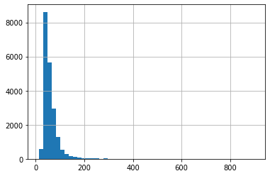

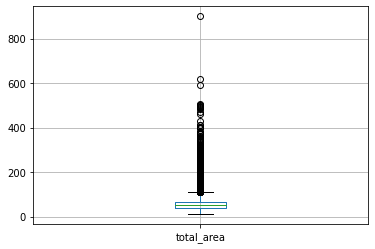

```python
characterize_hist_box(df=good_realty, col='total_area')
```

Очевидно, медиана площади квартиры находится в районе 50 кв.м., значения свыше 250 кв.м. являются единичными выбросами (их можно удалить), а достоверные значения предварительно, находятся в диапазоне от 10 до не более чем 250 кв.м.учтём это при построении диаграмм:

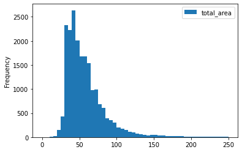

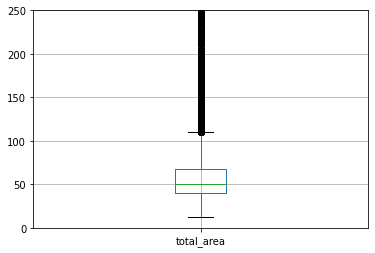

```python
# Построение диаграмм
good_realty.plot(y='total_area', kind='hist', bins=50, range=(0, 250))
plt.show()
plt.ylim(0, 250)
good_realty.boxplot(column='total_area')
plt.show()
```

Распределение общей площади квартир похоже на искажённое Пуассоновское, медиана находится в районе 50 кв.м., нижний ус диаграммы размаха упирается в минимальное значение общей площади, верхний - отсекает значения свыше 110.13 кв.м., считая их выбросами:

```python
characteristics = good_realty['total_area'].describe()
characteristics['75%'] + 1.5 *(characteristics['75%'] - characteristics['25%'])
```

```
110.13
```

Статистические характеристики столбца следующие:

- средняя площадь составляет около 58 кв.м.
- медиана - 50.8 кв.м.
- 25% квартир имеют площадь до 39.58 кв.м. (Q1)
- 75% квартир имеют площадь до 67.8 кв.м. (Q3)
- стандартное отклонение достаточно велико - 34.06, следовательно, велико влияние выбросов

Верхний ус диаграмы размаха отсекает всего около 5% значений:

```python
round(len(good_realty[good_realty['total_area'] > 110.13]) * 100 / len(good_realty), 2)
```

```
5.02
```

Удалим их и посмотрим, как изменится распределение:

```
count    19417.000000
mean        53.327463
std         18.616255
min         12.000000
25%         39.000000
50%         49.120000
75%         64.000000
max        110.200000
Name: total_area, dtype: float64
```

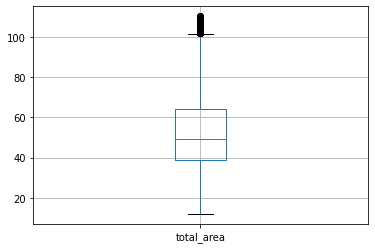

```python
# Удаление выбросов
good_realty = good_realty.query('total_area <= 110.25')

# Характеристика столбца
characterize_box(good_realty, 'total_area')
```

Характеристики распределения существенно улучшились.

#### Исследование распределения цены квартиры

Охарактеризуем столбец`'last_price'`, а также построим для него гистограмму на 50 корзин и диаграмму размаха:

```
count    1.941700e+04
mean     5.121432e+06
std      3.084219e+06
min      1.219000e+04
25%      3.330000e+06
50%      4.400000e+06
75%      6.025000e+06
max      5.300000e+07
Name: last_price, dtype: float64
```

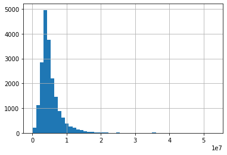

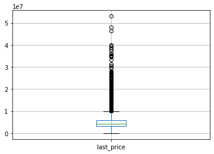

```python
characterize_hist_box(good_realty, 'last_price')
```

Очевидно, большинство адекватных значений стоимости сосредоточены в диапазоне до 10 млн. Кроме того, гистограмма показывает, что выбросы свыше 20 млн. - единичные (вероятно, их можно выбросить). Учтём это при построении диаграмм:

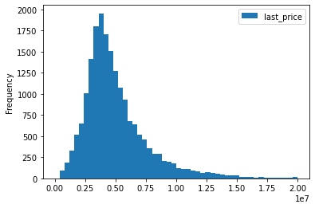

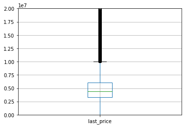

```python
# Построение диаграмм
good_realty.plot(y='last_price', kind='hist', bins=50, range=(0, 20000000))
plt.show()
plt.ylim(0, 20000000)
good_realty.boxplot(column='last_price')
plt.show()
```

```python
characteristics = good_realty['last_price'].describe()
characteristics['75%'] + 1.5 *(characteristics['75%'] - characteristics['25%'])
```

```
10067500.0
```

Статистические характеристики столбца следующие:

- средняя стоимость квартиры составляет около 5.12 млн.
- медиана - 4.4 млн.
- 25% квартир проданы по цене не выше 3.33 млн. (Q1)
- 75% квартир проданы по цене не выше 6 млн. (Q3)
- min цена составляет 12 190 руб.

Минимальная цена за квартиру настораживает. Рассмотрим квартиры с наименьшей стоимостью стоимостью в пределах до 1 млн.:

```python
good_realty.query('last_price < 1000000').sort_values(by='last_price').head()
```

|  | total_images | last_price | total_area | first_day_exposition | rooms | ceiling_height | floors_total | living_area | floor | is_apartment | ... | ponds_around_3000 | ponds_nearest | days_exposition | price_per_m2 | first_exposition_weekday | first_exposition_month | first_exposition_year | floor_cat | living_ratio | kitchen_ratio |
| --- | --- | --- | --- | --- | --- | --- | --- | --- | --- | --- | --- | --- | --- | --- | --- | --- | --- | --- | --- | --- | --- |
| 8793 | 7 | 12190.0 | 109.0 | 2019-03-20 | 2 | 2.75 | 25 | 32.0 | 25 | False | ... | 0.0 | NaN | 8 | 111.83 | 2 | 3 | 2019 | последний | 0.29 | 0.37 |
| 14911 | 5 | 430000.0 | 54.0 | 2018-06-26 | 2 | NaN | 3 | NaN | 3 | False | ... | NaN | NaN | 44 | 7962.96 | 1 | 6 | 2018 | последний | NaN | NaN |
| 16274 | 18 | 440000.0 | 40.0 | 2018-07-10 | 1 | NaN | 5 | NaN | 1 | False | ... | NaN | NaN | 45 | 11000.00 | 1 | 7 | 2018 | первый | NaN | NaN |
| 17676 | 0 | 450000.0 | 36.5 | 2018-02-01 | 1 | NaN | 5 | 17.3 | 4 | False | ... | NaN | NaN | 120 | 12328.77 | 3 | 2 | 2018 | другой | 0.47 | 0.23 |
| 16219 | 14 | 450000.0 | 38.5 | 2018-07-11 | 2 | 2.65 | 2 | NaN | 1 | False | ... | NaN | NaN | 45 | 11688.31 | 2 | 7 | 2018 | первый | NaN | NaN |

5 rows × 29 columns

Налицо аномальное несоответствие стоимости и площади самой дешёвой квартиры. Целесообразно удалить этот выброс (подходят все квартиры стоимостью выше 400 000). Верхний ус диаграммы размаха отсекает 5.81% объевлений:

```python
round(len(good_realty[good_realty['last_price'] > 10000000]) * 100 / len(good_realty), 2)
```

```
5.81
```

Очистим таблицу от аномальных значений. Оставим только квартиры стоимостью от 400 тысяч до 10 миллионов и посмотрим, как изменится распределение:

```
count    1.828800e+04
mean     4.579979e+06
std      1.905149e+06
min      4.300000e+05
25%      3.288450e+06
50%      4.265000e+06
75%      5.675512e+06
max      1.000000e+07
Name: last_price, dtype: float64
```

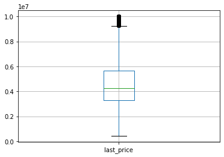

```python
# Удаление выбросов
good_realty = good_realty.query('last_price > 400000 and last_price <= 10000000')

# Характеристика столбца
characterize_box(good_realty, 'last_price')
```

На диаграмме размаха появился нижний ус! Характеристики распределения существенно улучшились.

#### Исследование распределения количества комнат

Охарактеризуем столбец `'rooms'`, а также построим для него гистограмму на 50 корзин и диаграмму размаха:

```
count    18288.000000
mean         1.861330
std          0.869274
min          0.000000
25%          1.000000
50%          2.000000
75%          2.000000
max          6.000000
Name: rooms, dtype: float64
```

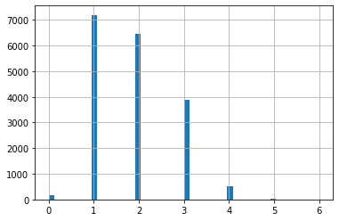

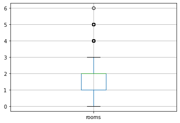

```python
characterize_hist_box(df=good_realty, col='rooms')
```

Распределение количества комнат похоже на Пуассоновское, медиана находится в районе 2, нижний ус диаграммы размаха упирается в 0, верхний - отсекает значения свыше 3, считая их выбросами.

Рассмотрим какие площади занимают квартиры от 4 комнат:

```python
good_realty.query('rooms >= 4')['total_area'].describe()
```

```
count    542.000000
mean      79.632841
std       17.267735
min       40.000000
25%       72.000000
50%       79.550000
75%       93.800000
max      110.200000
Name: total_area, dtype: float64
```

Данные характеристики хорошо соотносятся с живыми данными [Яндекс.Недвижимости](https://realty.yandex.ru/sankt-peterburg_i_leningradskaya_oblast/kupit/kvartira/4-i-bolee/?sort=AREA). В Санкт-Петербурге и окрестностях действительно существуют очень маленькие 4- и более комнатные квартиры.

Рассмотрим, однако, квартиры с 0 комнат. **Гипотеза** заключается в том, что ноль проставляют для квартир свободной планировки. Проверим её:

```python
round(
    good_realty.query('rooms == 0')['open_plan'].sum() * 100 / len(good_realty.query('rooms == 0')), 2
)
```

```
32.58
```

Неожиданно, но среди 0-комнатных квартир только 32.58% помечены, как свободная планировка. Очевидно, это ошибка ввода данных пользователем (забыли проставить "галочку"). 0-комнатных квартир фиксированной планировки не бывает.

Оценим характеристики значений общей полощади квартир, которые забыли пометить, как свободной планировки:

```python
good_realty.query('rooms == 0 and not open_plan')['total_area'].describe()
```

```
count    120.000000
mean      27.062333
std        7.406973
min       15.500000
25%       24.000000
50%       26.000000
75%       28.220000
max       73.600000
Name: total_area, dtype: float64
```

Площадь таких квартир явно не способна вместить 9 или 10 комнат, чтобы можно было говорить об ошибках ввода другой природы.

В идеале, надо было бы проставить значение `True` в поле `'open_plan'` для данных 120 квартир, однако эта информация далее использоваться не будет, поэтому оставим столбцы `'rooms'` и `'open_plan'` без изменений.

#### Исследование распределения высоты потолков

Охарактеризуем столбец `'ceiling_height'`, а также построим для него гистограмму на 50 корзин и диаграмму размаха:

```
count    10641.000000
mean         2.714174
std          0.942705
min          1.000000
25%          2.500000
50%          2.600000
75%          2.750000
max         27.500000
Name: ceiling_height, dtype: float64
```

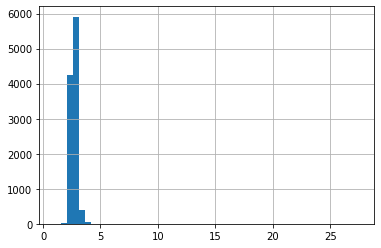

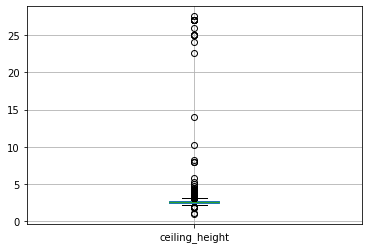

```python
characterize_hist_box(df=good_realty, col='ceiling_height')
```

Очевидно, большинство адекватных значений высоты сосредоточены в диапазоне до 3 метров. Кроме того, гистограмма показывает как выбросы свыше 4 метров - единичные (вероятно, их можно выбросить), так и менее 2.5 метров (вероятно, их также можно выбросить). Учтём это при построении диаграмм:

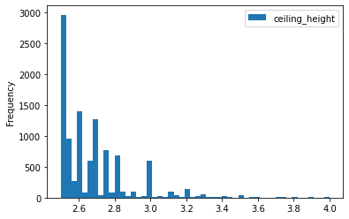

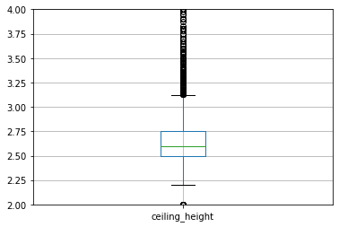

```python
# Построение диаграмм
good_realty.plot(y='ceiling_height', kind='hist', bins=50, range=(2.5, 4))
plt.show()
plt.ylim(2, 4)
good_realty.boxplot(column='ceiling_height')
plt.show()
```

Отметим, что высота потолков по аналогии с количеством комнат - дискретная величина. Этот факт нашел отражение на гистограмме, которая выглядит похожей на пуассоновское распределение дискретной случайной величины.

Медиана находится в районе 2.6 м., нижний ус диаграммы размаха отсекает значения менее 2.13 м., считая их выбросами:

```python
characteristics = good_realty['ceiling_height'].describe()
characteristics['25%'] - 1.5 * (characteristics['75%'] - characteristics['25%'])
```

```
2.125
```

Верхний ус отсекает значения свыше 3.13 м., считая их выбросами:

```python
characteristics['75%'] + 1.5 * (characteristics['75%'] - characteristics['25%'])
```

```
3.125
```

Для дальнейших рассуждений аномально большие и малые значения высоты лучше убрать. Усы диаграмы размаха отсекают всего 2.65% значений:

```python
round(len(good_realty.query('ceiling_height < 2.125 or ceiling_height > 3.125')) * 100 /
      len(good_realty), 2)
```

```
2.65
```

Удалить их, сохранив имеющиеся пропуски в данном столбце, с использованием срезов нельзя, поскольку они удалят и пропуски, которых в данном столбце гораздо больше, чем аномальных значений:

```python
round(good_realty['ceiling_height'].isna().sum() * 100 / len(good_realty), 2)
```

```
41.81
```

Терять почти 42% записей в таблице не целесообразно. Тем более, что в целом характеристики распределения высоты потолков удовлетворительны, а выбросы - очень редки.

Избавимся от выбросов, заменив их на заведомо большое значение (например, 400) с использованием метода where(), а затем удалив соответствующие строки методом drop():

```python
# Замена выбросов в 'ceiling_height' на 400
good_realty['ceiling_height'].where(
    (
        (good_realty['ceiling_height'].isna()) |
        ((good_realty['ceiling_height'] >= 2.125) & (good_realty['ceiling_height'] <= 3.125))
    ),
    400,
    inplace=True
)

# Удаление строк, в которых 'ceiling_height' == 400
good_realty.drop(
    labels=good_realty.query('ceiling_height == 400').index,
    axis=0,
    inplace=True
)
```

Рассмотрим обновлённое распределение:

```
count    10156.000000
mean         2.644355
std          0.149589
min          2.200000
25%          2.500000
50%          2.600000
75%          2.730000
max          3.120000
Name: ceiling_height, dtype: float64
```

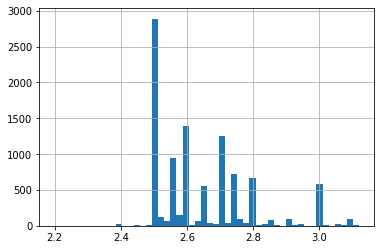

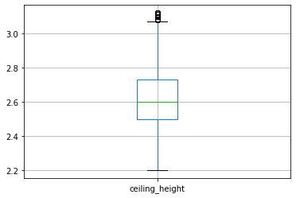

```python
characterize_hist_box(df=good_realty, col='ceiling_height')
```

Характеристики распределения существенно улучшились.